# sem

2022-12-06

```r
library(here)

library(tidyverse)
library(magrittr)
library(piecewiseSEM)
library(nlme)
library(lmerTest)
library(mgcv)
library(dagitty)
```

Read in data

```r
comm_data <- readRDS(here("processed_data","comm_data.rds"))
```

# Intro

The purpose of this script was to try out SEM with the ranavirus data to answer whether there were direct or indirect effects of temperature on infection prevalence that were possible being mediated by abundance or community competence. SEM can help us to understand relationships between multiple variables that may be causally related to each other.

Make lagged data - I’ll use this later to compare results using lagged and not lagged data

```r
prev_cc <- comm_data

order <- prev_cc[order(prev_cc$WetAltID, prev_cc$Month.1),]

#this removes months out of sequence
order <- order[-c(4,14,47,90),]

order %<>% add_column(lag_cc = NA, lag_size = NA, lag_temp = NA)


#create new column that includes previous month's value for cc
for(n in 2:nrow(order)){
  order$lag_cc[n] <- order$cc[n-1]
  order$lag_size[n] <- order$size[n-1]
  order$lag_temp[n] <- order$MeanWaterTempPredC[n-1]
}

#remove the first entry for each wetland to remove the carryover from the last wetland
clean <- order %>% group_by(WetAltID) %>% filter(duplicated(WetAltID) | n()==1)
```

```r
comm_data %<>% filter(!is.na(MeanWaterTempPredC)) #remove missing water temp data
clean %<>% filter(!is.na(MeanWaterTempPredC))
```

This is just a way to visualize the SEM. I think it must have a method for customizing the orientation of things to make it look nicer but I haven’t tried to figure out how to do that.

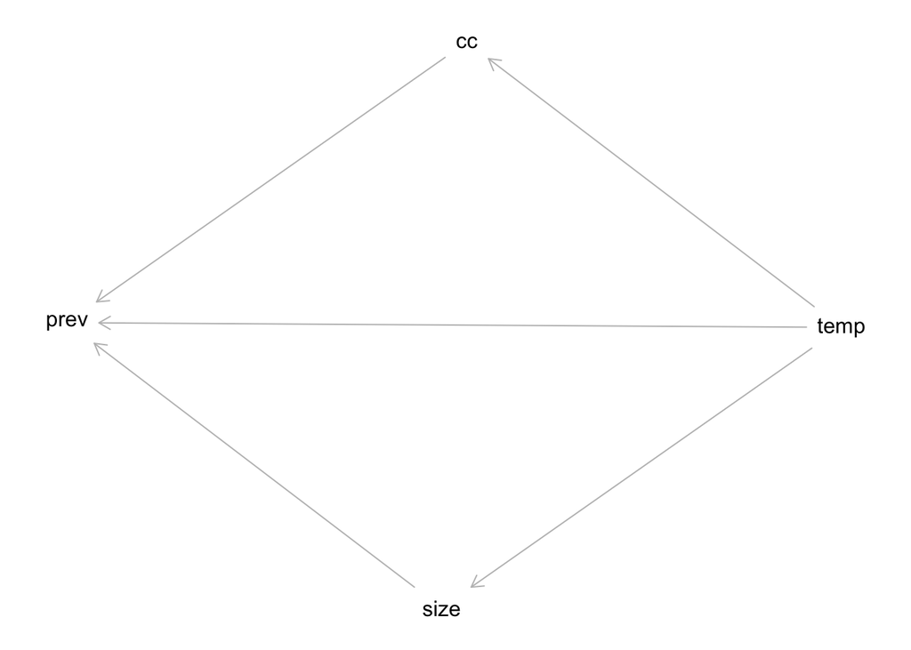

```r
prev_mod <- dagitty("dag{
  temp -> cc
  temp -> size
  temp -> prev
  cc -> prev
  size -> prev
             }")

plot(graphLayout(prev_mod))
```

Just some histograms to check the distributions of the data

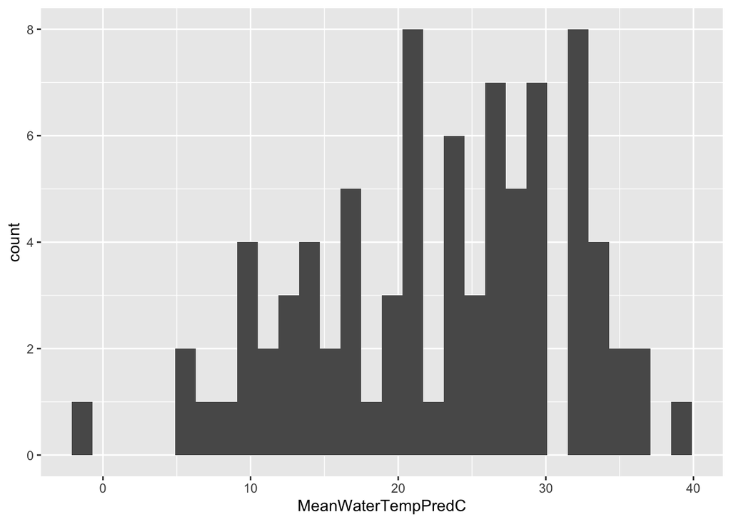

```r
comm_data %>% ggplot(.,aes(x=MeanWaterTempPredC)) + geom_histogram()
```

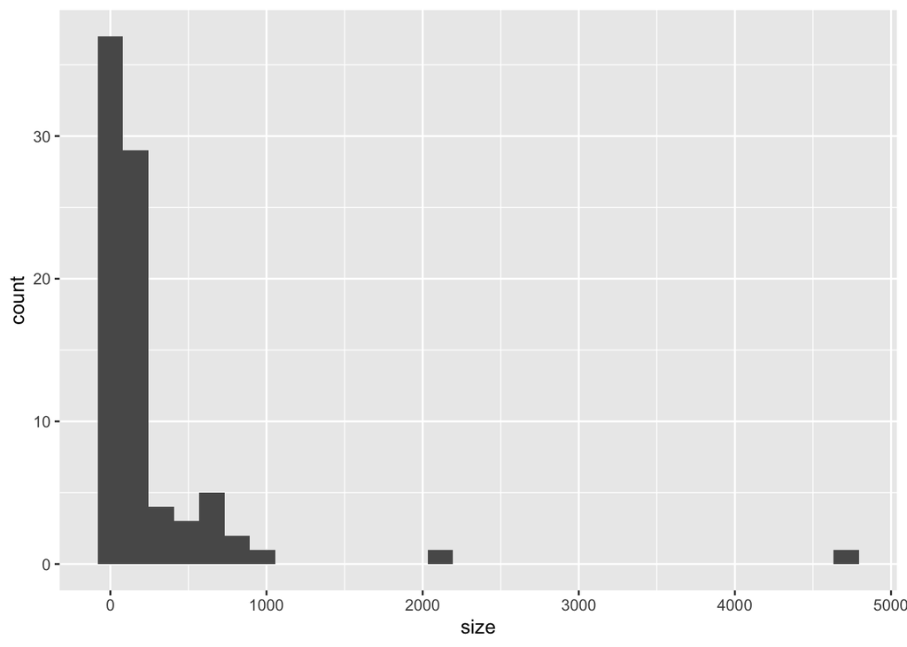

```r
comm_data %>% ggplot(.,aes(x=size)) + geom_histogram()
```

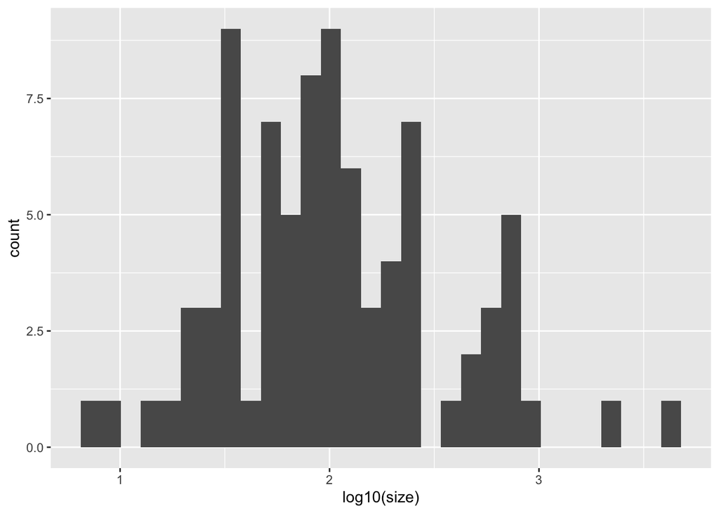

```r
comm_data %>% ggplot(.,aes(x=log10(size))) + geom_histogram()
```

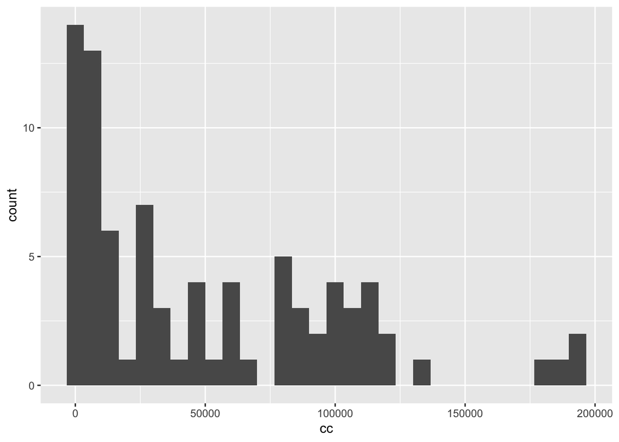

```r
comm_data %>% ggplot(.,aes(x=cc)) + geom_histogram()
```

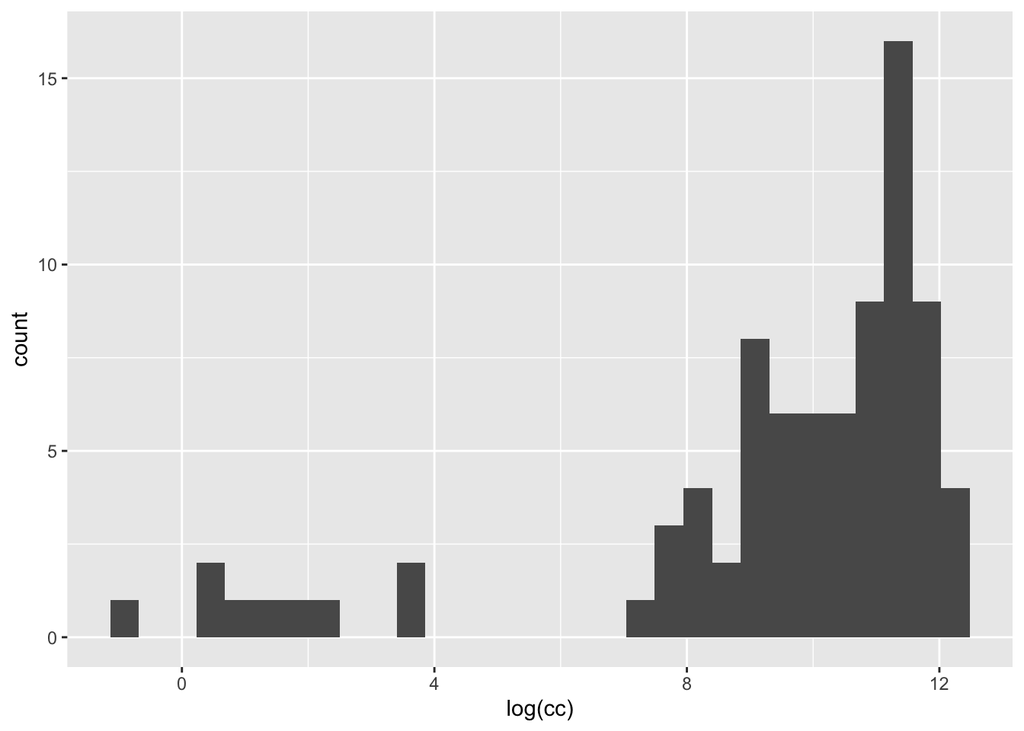

```r
comm_data %>% ggplot(.,aes(x=log(cc))) + geom_histogram()
```

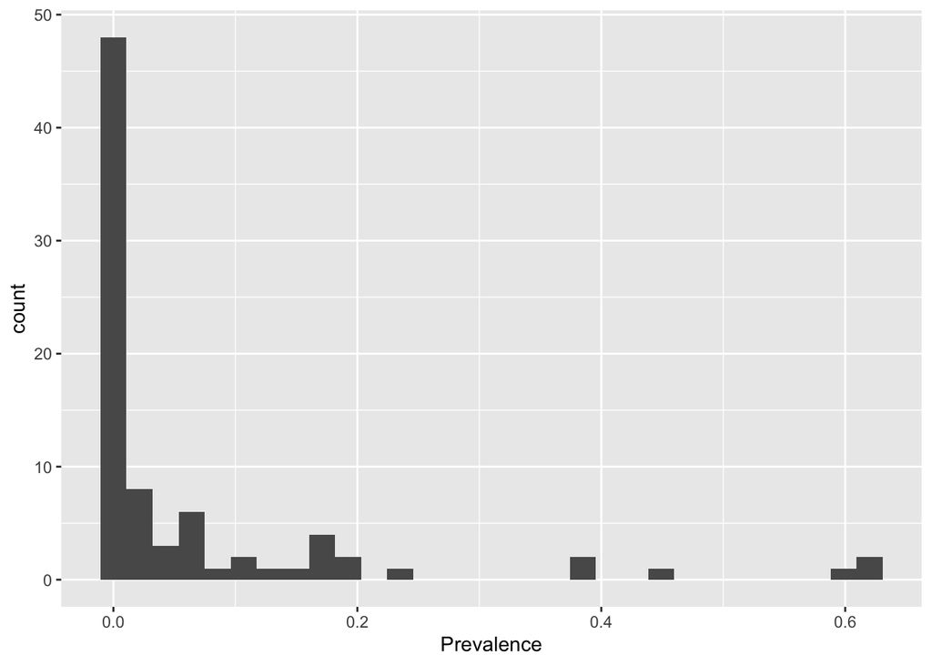

```r
comm_data %>% ggplot(.,aes(x=Prevalence)) + geom_histogram()
```

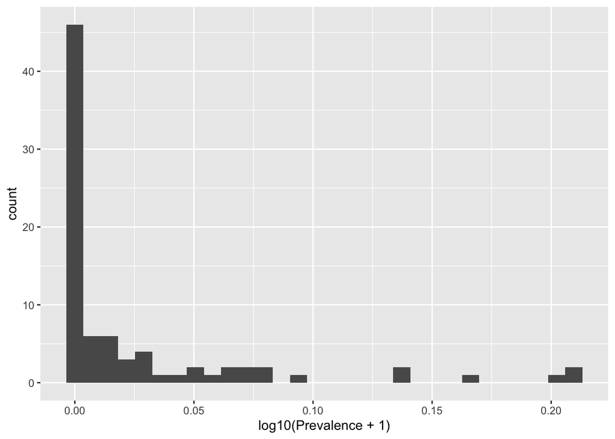

```r
comm_data %>% ggplot(.,aes(x=log10(Prevalence+1))) + geom_histogram()
```

And some basic plots for all the univariate relationships I am considering

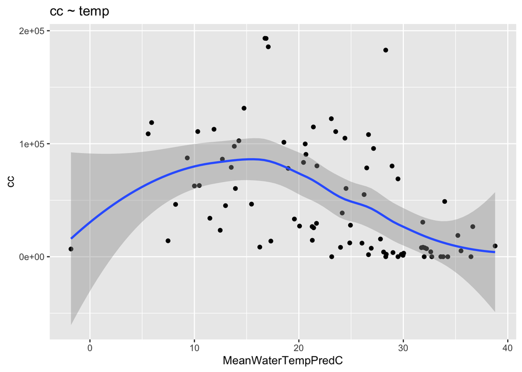

```r
comm_data %>% ggplot(.,aes(x=MeanWaterTempPredC, y = cc)) + geom_point() + geom_smooth() +
  labs(title = "cc ~ temp")
```

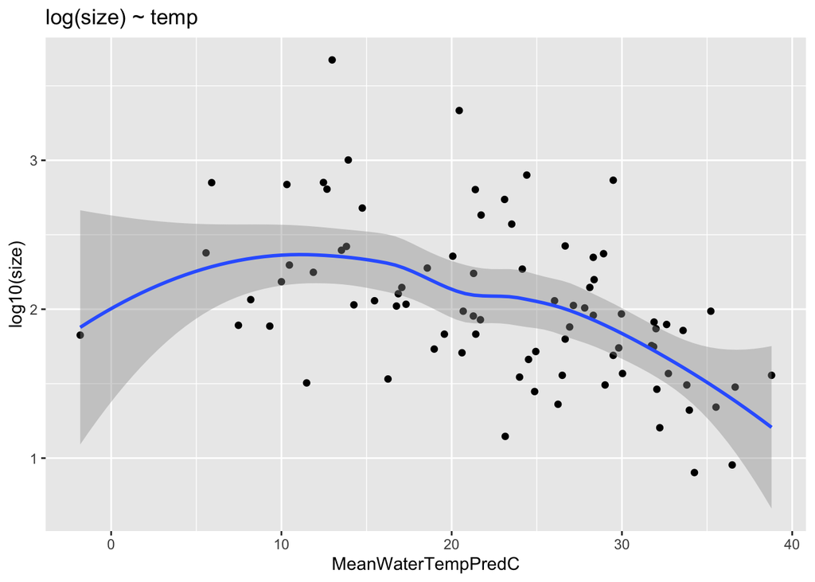

```r
comm_data %>% ggplot(.,aes(x=MeanWaterTempPredC, y = log10(size))) + geom_point() + geom_smooth() +
  labs(title = "log(size) ~ temp")
```